[output not shown]

### The Determinants of Serve Speed in Professional Tennis

In tennis, the serve is far more than just the starting point of a rally — it is one of the most decisive shots in the game. A powerful serve can earn a player a free point, limit their opponent’s ability to return aggressively, and dictate the flow of the entire match. At the highest levels of professional tennis, serve speed is considered a critical competitive advantage, which raises an important question: what factors actually determine how fast an ATP player can serve?

This paper investigates the determinants of average serve speed among professional ATP players through a series of regression analyses. We examine both physical characteristics — including height, weight, and age — as well as experiential and equipment-related variables, such as years on tour and racket specifications. Our central research question is: to what extent do a player’s physical attributes, professional experience, and equipment explain variation in average serve speed? More specifically, we ask whether natural physical factors or acquired, controllable factors are the stronger predictors of performance.

Understanding what drives serve speed also carries meaningful economic implications. If serve speed is primarily determined by physical traits, it becomes a more predictable variable for sports analysts, bettors, and scouts — offering an edge in forecasting match outcomes based on player profiles. On the other hand, if equipment plays a significant role, racket manufacturers have a tangible, data-backed basis for marketing performance claims, much as footwear and apparel brands have done in other sports. Either finding has real consequences for how money flows through the tennis industry.

We hypothesize that physical attributes — particularly height — will be the strongest predictor of serve speed, as taller players benefit from a more favorable serving angle and a longer swing arc, allowing them to generate greater velocity more naturally. Weight and age are also expected to be significant physical factors, with serve speed likely peaking during a player’s prime years and declining thereafter. While we expect racket specifications — such as racket weight and string tension — to have a meaningful impact on serve speed as well, we anticipate their effect to be secondary to that of physical traits, since equipment can optimize performance but cannot fully compensate for the bio mechanical advantages conferred by a player’s body. To test these hypotheses, our data set includes player-level statistics from the ATP tour, comprising physical measurements, equipment specifications, and career statistics. Our findings confirm that height is the dominant and most robust determinant of serve speed, while most other variables — including age, equipment, and handedness — do not reach statistical significance in the full sample.

### Data and variables

- hgt - height - positive correlation
- wgt - weight - positive correlation (multicollinearity w height)
- age - age - negative
- rank - ATP/WTA ranking - positive,
- mtch - number of matches played/year - unknown
- rhsize - racket head size - negative,
- fstserve - first serve percentage - negative
- dblfault - double faults - positive
- gen - gender - male (1) players serve faster than female (0) player (standby for now).
- rhand - Right(1)/left(0)-handed - unknown
- Unobservable (omitted) variable:*
- Toss height (point of impact) - positive correlation with height and serve speed (positive bias).

```r
# Partial data
tennis.data <- read_excel("econ-research_test.xlsx")

summary(tennis.data)
```

```
##      Name                rank         age             hgt
##  Length:21          Min.   : 1   Min.   :20.00   Min.   :180.0
##  Class :character   1st Qu.: 6   1st Qu.:24.00   1st Qu.:185.0
##  Mode  :character   Median :11   Median :27.00   Median :188.0
##                     Mean   :11   Mean   :26.24   Mean   :189.4
##                     3rd Qu.:16   3rd Qu.:28.00   3rd Qu.:196.0
##                     Max.   :21   Max.   :38.00   Max.   :198.0
##      rhand             mtch           rhsize          1serve
##  Min.   :0.0000   Min.   :39.00   Min.   :612.0   Min.   :56.00
##  1st Qu.:1.0000   1st Qu.:56.00   1st Qu.:632.0   1st Qu.:61.00
##  Median :1.0000   Median :64.00   Median :632.0   Median :63.00
##  Mean   :0.9048   Mean   :62.81   Mean   :634.1   Mean   :63.19
##  3rd Qu.:1.0000   3rd Qu.:70.00   3rd Qu.:645.0   3rd Qu.:66.00
##  Max.   :1.0000   Max.   :82.00   Max.   :645.0   Max.   :72.00
##      2fault         avgspeed
##  Min.   : 91.0   Min.   :182.0
##  1st Qu.:134.0   1st Qu.:187.0
##  Median :152.0   Median :192.0
##  Mean   :165.7   Mean   :190.9
##  3rd Qu.:198.0   3rd Qu.:195.0
##  Max.   :299.0   Max.   :203.0
```

```r
#rename column by name
colnames(tennis.data)[colnames(tennis.data) == '1serve'] <- 'frtserve'
colnames(tennis.data)[colnames(tennis.data) == '2fault'] <- 'dblfault'
```

```r
# Completed data set
fulldata <- read_excel("econ.research_v1 (1).xlsx")

summary(fulldata)
```

```
##      Name                rank             age             hgt
##  Length:100         Min.   :  1.00   Min.   :19.00   Min.   :170.0
##  Class :character   1st Qu.: 25.75   1st Qu.:24.00   1st Qu.:183.0
##  Mode  :character   Median : 50.50   Median :26.00   Median :188.0
##                     Mean   : 50.50   Mean   :26.73   Mean   :187.4
##                     3rd Qu.: 75.25   3rd Qu.:29.00   3rd Qu.:193.0
##                     Max.   :100.00   Max.   :39.00   Max.   :211.0
##      rhand           mtch           rhsize          1serve        2faults
##  Min.   :0.00   Min.   : 8.00   Min.   :600.0   Min.   :52.0   Min.   :  8.00
##  1st Qu.:1.00   1st Qu.:30.75   1st Qu.:632.0   1st Qu.:60.0   1st Qu.: 79.75
##  Median :1.00   Median :42.00   Median :632.0   Median :62.0   Median :115.50
##  Mean   :0.87   Mean   :43.00   Mean   :632.9   Mean   :62.4   Mean   :120.82
##  3rd Qu.:1.00   3rd Qu.:56.00   3rd Qu.:633.8   3rd Qu.:65.0   3rd Qu.:152.00
##  Max.   :1.00   Max.   :82.00   Max.   :645.0   Max.   :72.0   Max.   :302.00
##     avgspeed
##  Min.   :171.0
##  1st Qu.:184.0
##  Median :189.5
##  Mean   :189.1
##  3rd Qu.:193.2
##  Max.   :214.0
```

```r
#rename column by name
colnames(fulldata)[colnames(fulldata) == '1serve'] <- 'frtserve'
colnames(fulldata)[colnames(fulldata) == '2faults'] <- 'dblfault'
```

### List of Future Regressions

$$ServeSpeed =\beta_0 + \beta_1 hgt + \mu$$

$$ServeSpeed =\beta_0 + \beta_1 hgt +
\beta_2 hgt^2 + \mu$$

$$ServeSpeed =\beta_0 + \beta_1 age +
\beta_2 hgt + \mu$$

$$ServeSpeed =\beta_0 + \beta_1 age +
\beta_2 hgt + \beta_3 (hgt)^2 + \mu$$

$$ServeSpeed =\beta_0 + \beta_1 rank +
\beta_2 age + \beta_3 hgt + \beta_4 rhand + \beta_5 mtch + \beta_6
rhsize + \beta_7 fstserve + \beta_8 dblfault + \mu$$

### Test Regression

```r
reg_test <- lm(avgspeed ~ age + hgt, data=tennis.data)
summary(reg_test)
```

```
##
## Call:
## lm(formula = avgspeed ~ age + hgt, data = tennis.data)
##
## Residuals:
##     Min      1Q  Median      3Q     Max
## -6.7942 -2.4501  0.1359  2.3970  7.7127
##
## Coefficients:
##             Estimate Std. Error t value Pr(>|t|)
## (Intercept)  76.2443    26.1425   2.916 0.009211 **
## age          -0.5860     0.2284  -2.566 0.019451 *
## hgt           0.6866     0.1397   4.916 0.000111 ***
## ---
## Signif. codes:  0 '***' 0.001 '**' 0.01 '*' 0.05 '.' 0.1 ' ' 1
##
## Residual standard error: 3.834 on 18 degrees of freedom
## Multiple R-squared:  0.6026, Adjusted R-squared:  0.5585
## F-statistic: 13.65 on 2 and 18 DF,  p-value: 0.000247
```

Age was found to have a statistically significant negative effect on serve speed. Specifically, each additional year of age is associated with a decrease in average serve speed of 0.586 km/h, holding all other variables constant. This result is significant at the 95% confidence level, suggesting that as players grow older, their serve speed tends to decline — consistent with the expected reduction in physical explosiveness and swing speed that accompanies aging.

Height was found to have a statistically significant positive effect on serve speed, and represents the strongest predictor in this initial model. Each additional centimeter of height is associated with an increase in average serve speed of 0.687 km/h, holding all other variables constant. This result is significant at the 99.9% confidence level, providing strong evidence that taller players are able to generate greater serve velocity. This is consistent with our hypothesis: greater height raises the point of ball contact, creates a more favorable angle into the service box, and allows for a longer swing arc — all of which contribute to higher serve speeds.

### Regression 1 & 2: Height

$$ServeSpeed =\beta_0 + \beta_1 hgt + \mu$$

$$ServeSpeed =\beta_0 + \beta_1 hgt +
\beta_2 hgt^2 + \mu$$

```r
heigth_reg <- lm(avgspeed ~ hgt, data = fulldata)
summary(heigth_reg)
```

```
##
## Call:
## lm(formula = avgspeed ~ hgt, data = fulldata)
##
## Residuals:
##      Min       1Q   Median       3Q      Max
## -14.4621  -3.6725   0.2201   3.2433  14.4073
##
## Coefficients:
##             Estimate Std. Error t value Pr(>|t|)
## (Intercept) 45.56042   14.65266   3.109  0.00245 **
## hgt          0.76633    0.07815   9.805  3.2e-16 ***
## ---
## Signif. codes:  0 '***' 0.001 '**' 0.01 '*' 0.05 '.' 0.1 ' ' 1
##
## Residual standard error: 5.338 on 98 degrees of freedom
## Multiple R-squared:  0.4952, Adjusted R-squared:  0.4901
## F-statistic: 96.15 on 1 and 98 DF,  p-value: 3.201e-16
```

```r
## Height Squared

hgt_sq <- fulldata$hgt^2
heigthsq_reg <- lm(avgspeed ~ hgt + hgt_sq, data = fulldata)
summary(heigthsq_reg)
```

```
##
## Call:
## lm(formula = avgspeed ~ hgt + hgt_sq, data = fulldata)
##
## Residuals:
##      Min       1Q   Median       3Q      Max
## -14.4467  -3.6508   0.2227   3.2567  14.3497
##
## Coefficients:
##              Estimate Std. Error t value Pr(>|t|)
## (Intercept) 6.476e+01  2.614e+02   0.248    0.805
## hgt         5.624e-01  2.773e+00   0.203    0.840
## hgt_sq      5.406e-04  7.349e-03   0.074    0.942
##
## Residual standard error: 5.365 on 97 degrees of freedom
## Multiple R-squared:  0.4953, Adjusted R-squared:  0.4848
## F-statistic: 47.59 on 2 and 97 DF,  p-value: 3.973e-15
```

```r
## heteroskedasticity test
bptest(avgspeed ~ hgt + hgt_sq, data = fulldata, studentize = TRUE)
```

```
##
##  studentized Breusch-Pagan test
##
## data:  avgspeed ~ hgt + hgt_sq
## BP = 0.27726, df = 2, p-value = 0.8705
```

The squared term for height was tested but found to be insignificant, confirming a linear relationship between height and serve speed. For this reason, it will be excluded from the future regressions.

### Regression 3: Height and Age

$$ServeSpeed =\beta_0 + \beta_1 age +
\beta_2 hgt + \mu$$

$$ServeSpeed =\beta_0 + \beta_1 age +
\beta_2 hgt + \beta_3 (hgt)^2 + \mu$$

```r
hgtage_reg <- lm(avgspeed ~ age + hgt, data = fulldata)
summary(hgtage_reg)
```

```
##
## Call:
## lm(formula = avgspeed ~ age + hgt, data = fulldata)
##
## Residuals:
##      Min       1Q   Median       3Q      Max
## -14.7349  -3.6192   0.1203   3.0920  13.6779
##
## Coefficients:
##             Estimate Std. Error t value Pr(>|t|)
## (Intercept) 47.23993   14.76341   3.200  0.00186 **
## age         -0.12756    0.13320  -0.958  0.34063
## hgt          0.77556    0.07878   9.845  2.9e-16 ***
## ---
## Signif. codes:  0 '***' 0.001 '**' 0.01 '*' 0.05 '.' 0.1 ' ' 1
##
## Residual standard error: 5.34 on 97 degrees of freedom
## Multiple R-squared:    0.5,  Adjusted R-squared:  0.4896
## F-statistic: 48.49 on 2 and 97 DF,  p-value: 2.524e-15
```

```r
hgtsqage_reg <- lm(avgspeed ~ age + hgt + hgt_sq, data = fulldata)
summary(hgtsqage_reg)
```

```
##
## Call:
## lm(formula = avgspeed ~ age + hgt + hgt_sq, data = fulldata)
##
## Residuals:
##      Min       1Q   Median       3Q      Max
## -14.7293  -3.6209   0.1201   3.0957  13.6595
##
## Coefficients:
##               Estimate Std. Error t value Pr(>|t|)
## (Intercept)  53.700177 261.769797   0.205    0.838
## age          -0.127392   0.134073  -0.950    0.344
## hgt           0.706916   2.778312   0.254    0.800
## hgt_sq        0.000182   0.007363   0.025    0.980
##
## Residual standard error: 5.368 on 96 degrees of freedom
## Multiple R-squared:    0.5,  Adjusted R-squared:  0.4843
## F-statistic: 31.99 on 3 and 96 DF,  p-value: 2.008e-14
```

Checking for heteroskedasticity:

```r
reg_3 <- lm(avgspeed ~ age + hgt, data = fulldata)
summary(reg_3)
```

```
##
## Call:
## lm(formula = avgspeed ~ age + hgt, data = fulldata)
##
## Residuals:
##      Min       1Q   Median       3Q      Max
## -14.7349  -3.6192   0.1203   3.0920  13.6779
##
## Coefficients:
##             Estimate Std. Error t value Pr(>|t|)
## (Intercept) 47.23993   14.76341   3.200  0.00186 **
## age         -0.12756    0.13320  -0.958  0.34063
## hgt          0.77556    0.07878   9.845  2.9e-16 ***
## ---
## Signif. codes:  0 '***' 0.001 '**' 0.01 '*' 0.05 '.' 0.1 ' ' 1
##
## Residual standard error: 5.34 on 97 degrees of freedom
## Multiple R-squared:    0.5,  Adjusted R-squared:  0.4896
## F-statistic: 48.49 on 2 and 97 DF,  p-value: 2.524e-15
```

```r
bptest(avgspeed ~ age + hgt, data = fulldata, studentize=TRUE)
```

```
##
##  studentized Breusch-Pagan test
##
## data:  avgspeed ~ age + hgt
## BP = 2.0832, df = 2, p-value = 0.3529
```

```r
reg3_fit <- fitted(reg_3)
reg3_res <- residuals(reg_3)
reg3_res_sq <- reg3_res^2
reg3_fit_sq <- reg3_fit^2

reg3_w_test <- lm(reg3_res_sq ~ reg3_fit + reg3_fit_sq, data = fulldata)


reg3_n <- nrow(fulldata)
reg3_r2 <- summary(reg3_w_test)$r.squared
reg3_lm_stat <- reg3_n*reg3_r2
reg3_lm_stat
```

```
## [1] 0.6087459
```

```r
pchisq(reg3_lm_stat, df=2, lower.tail = FALSE)
```

```
## [1] 0.7375857
```

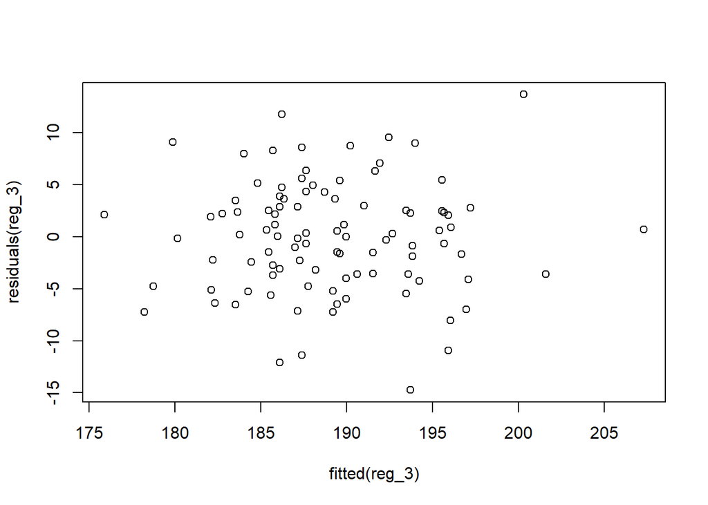

```r
plot(fitted(reg_3), residuals(reg_3))
```

### Regression 4: All Variables

```r
every_reg <- lm(avgspeed ~ rank + age + hgt + rhand + rhsize + frtserve + dblfault, data = fulldata)
summary(every_reg)
```

```
##
## Call:
## lm(formula = avgspeed ~ rank + age + hgt + rhand + rhsize + frtserve +
##     dblfault, data = fulldata)
##
## Residuals:
##      Min       1Q   Median       3Q      Max
## -13.8198  -3.5004   0.3664   2.9893  10.9931
##
## Coefficients:
##              Estimate Std. Error t value Pr(>|t|)
## (Intercept) -18.86901   46.12110  -0.409   0.6834
## rank          0.03480    0.02321   1.500   0.1372
## age          -0.12046    0.13088  -0.920   0.3598
## hgt           0.78091    0.08322   9.384 4.52e-15 ***
## rhand         2.08708    1.57028   1.329   0.1871
## rhsize        0.10854    0.06302   1.722   0.0884 .
## frtserve     -0.17404    0.15513  -1.122   0.2648
## dblfault      0.02904    0.01134   2.562   0.0120 *
## ---
## Signif. codes:  0 '***' 0.001 '**' 0.01 '*' 0.05 '.' 0.1 ' ' 1
##
## Residual standard error: 5.159 on 92 degrees of freedom
## Multiple R-squared:  0.5574, Adjusted R-squared:  0.5238
## F-statistic: 16.55 on 7 and 92 DF,  p-value: 5.945e-14
```

Testing for heteroskedasticity

```r
reg_6 <- lm(avgspeed ~ age + hgt + rhand + rhsize + frtserve + dblfault, data = fulldata)
summary(reg_6)
```

```
##
## Call:
## lm(formula = avgspeed ~ age + hgt + rhand + rhsize + frtserve +
##     dblfault, data = fulldata)
##
## Residuals:
##      Min       1Q   Median       3Q      Max
## -14.1426  -3.5700   0.6122   3.0858  12.5616
##
## Coefficients:
##              Estimate Std. Error t value Pr(>|t|)
## (Intercept)  0.815299  44.509278   0.018   0.9854
## age         -0.103428   0.131256  -0.788   0.4327
## hgt          0.761400   0.082747   9.201    1e-14 ***
## rhand        2.208687   1.578678   1.399   0.1651
## rhsize       0.091929   0.062453   1.472   0.1444
## frtserve    -0.224139   0.152506  -1.470   0.1450
## dblfault     0.019157   0.009285   2.063   0.0419 *
## ---
## Signif. codes:  0 '***' 0.001 '**' 0.01 '*' 0.05 '.' 0.1 ' ' 1
##
## Residual standard error: 5.193 on 93 degrees of freedom
## Multiple R-squared:  0.5466, Adjusted R-squared:  0.5174
## F-statistic: 18.69 on 6 and 93 DF,  p-value: 3.776e-14
```

```r
bptest(avgspeed ~ age + hgt + hgt_sq + rhand + rhsize + frtserve + dblfault, data = fulldata, studentize=TRUE)
```

```
##
##  studentized Breusch-Pagan test
##
## data:  avgspeed ~ age + hgt + hgt_sq + rhand + rhsize + frtserve + dblfault
## BP = 7.8928, df = 7, p-value = 0.3421
```

```r
reg6_fit <- fitted(reg_6)
reg6_res <- residuals(reg_6)
reg6_res_sq <- reg6_res^2
reg6_fit_sq <- reg6_fit^2

reg6_w_test <- lm(reg6_res_sq ~ reg6_fit + reg6_fit_sq, data = fulldata)


reg6_n <- nrow(fulldata)
reg6_r2 <- summary(reg6_w_test)$r.squared
reg6_lm_stat <- reg6_n*reg6_r2
reg6_lm_stat
```

```
## [1] 0.8259121
```

```r
pchisq(reg6_lm_stat, df=2, lower.tail = FALSE)
```

```
## [1] 0.6616914
```

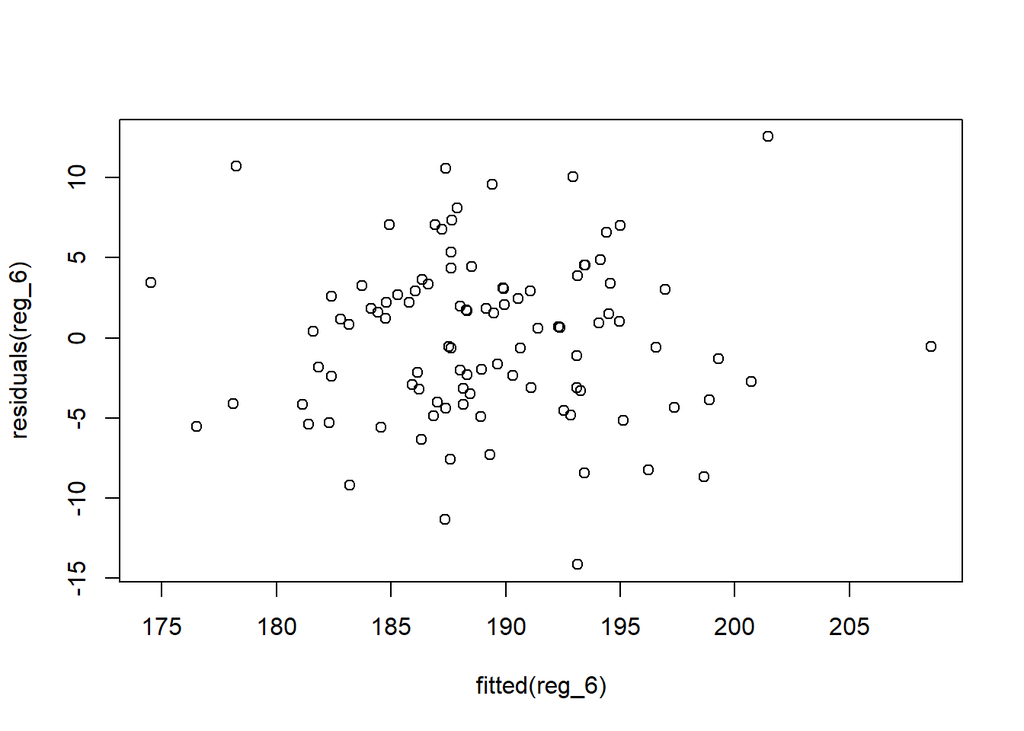

```r
plot(fitted(reg_6), residuals(reg_6))
```

This model does not suffer from heteroskedasticity. We can trust the significance/standard error to be correct.

The primary endogeneity concern in this model is the omitted variable of toss height/point of contact, which we already identified in our original variable list. This variable is positively correlated with both height (taller players make contact higher with the ball) and serve speed, meaning height’s coefficient may carry a slight upward bias. Since toss height is unavailable to us from the official ATP data, it cannot be directly controlled for in our regression. However, because it is largely a function of height itself, we believe the bias to be insignificant. A second concern is reverse causality between double faults and serve speed, as players usually decrease serve speed because they are already double-faulting frequently. It becomes a matter of strategy more than a matter of physical capabilities.

[figure not shown]

```r
boxplot(fulldata$avgspeed,
        data = fulldata,
        main="Average Serve Speed",
        xlab = "",
        ylab = "Height",
        col = "orange",
        border = "brown"
        )
```

```r
small <- ifelse(fulldata$hgt<205, 1, 0)

reg_6 <- lm(avgspeed ~ age + hgt + rhand + rhsize + frtserve + dblfault, data = fulldata)
summary(reg_6)
```

Call: lm(formula = avgspeed ~ age + hgt + rhand + rhsize + frtserve + dblfault, data = fulldata)

Residuals: Min 1Q Median 3Q Max -14.1426 -3.5700 0.6122 3.0858 12.5616

Residual standard error: 5.193 on 93 degrees of freedom Multiple R-squared: 0.5466, Adjusted R-squared: 0.5174 F-statistic: 18.69 on 6 and 93 DF, p-value: 3.776e-14

```r
reg_7 <- lm(avgspeed ~ age + hgt + rhand + rhsize + frtserve + dblfault + small, data = fulldata)
summary(reg_7)
```

Call: lm(formula = avgspeed ~ age + hgt + rhand + rhsize + frtserve + dblfault + small, data = fulldata)

Residuals: Min 1Q Median 3Q Max -14.1649 -3.5891 0.5826 3.0770 12.5015

Residual standard error: 5.221 on 92 degrees of freedom Multiple R-squared: 0.5467, Adjusted R-squared: 0.5122 F-statistic: 15.85 on 7 and 92 DF, p-value: 1.711e-13

```r
htmlreg(list(reg_6, reg_7),
        stars=c(0.01,0.05,0.1),
        caption = "Dep Var: R&D Intensity",
        star.symbol = "\\*",
        caption.above = TRUE,
        custom.model.names=c("Baseline", "No Outlier"),
        digits=4)
```

|  | Baseline | No Outlier |
| --- | --- | --- |
| (Intercept) | 0.8153 | -0.8111 |
|  | (44.5093) | (46.9450) |
| age | -0.1034 | -0.1034 |
|  | (0.1313) | (0.1320) |
| hgt | 0.7614*** | 0.7648*** |
|  | (0.0827) | (0.0883) |
| rhand | 2.2087 | 2.2062 |
|  | (1.5787) | (1.5873) |
| rhsize | 0.0919 | 0.0925 |
|  | (0.0625) | (0.0630) |
| frtserve | -0.2241 | -0.2249 |
|  | (0.1525) | (0.1534) |
| dblfault | 0.0192** | 0.0192** |
|  | (0.0093) | (0.0094) |
| small |  | 0.6450 |
|  |  | (5.6296) |
| R<sup>2</sup> | 0.5466 | 0.5467 |
| Adj. R<sup>2</sup> | 0.5174 | 0.5122 |
| Num. obs. | 100 | 100 |

***p < 0.01; **p < 0.05; *p < 0.1

## Conclusion

This paper examined the determinants of average serve speed among the top 100 ATP players using OLS regression analysis. Across all model specifications, height emerged as the singular robust predictor of serve speed, with each centimeter of additional height associated with approximately 0.76 km/h of additional speed. Double faults — interpreted here as a proxy for serve aggression — were the only other variable to reach statistical significance. Age, our dummy variable for being right or left handed, racket head size, and first-serve percentage were not statistically significant once height was included in the model. These results carry meaningful implications. For sports analysts and bettors, serve speed is largely a function of a fixed physical trait, making it a predictable input for match forecasting. For equipment manufacturers, the lack of significance for racket head size suggests that at the professional level, players have already optimized their gear, and performance differences are driven by the athlete, not the equipment. The primary limitation of this study is sample size (n=100) and the cross-sectional nature of the data. Longitudinal data tracking individual players over time would allow for stronger causal claims, particularly regarding age-related decline. Future work should also explore the inclusion of toss height or point-of-contact data, which remains the key unobservable in this analysis.